# Deep Neuron Network-based Cancer Origin Classifier

*Chunlei Zheng, Rong Xu*

**7-7-2019**

# Table of Contents

## 1 Project Description

Identification of cancer tissue of origin is a routine in clinical practice in oncology. This is typically carried out with immunohistochemistry panels on the tumor specimen and imaging tests. Some cancer origins are easy to be determined and others are very difficult, especially for metastatic and un-differentially cancer. Accumulative evidence indicates that site-specific treatments improve patient outcomes. However, pathologic-based procedures need considerable resources, time, and expense. In addition, it can only achieve 66-88% of accuracy in metastatic cancer. Existing gene expression- or microRNA-based techniques also have limited performance.

We developed a deep neuron network (DNN)-based tissue of origin classifier using DNA methylation data of 7,339 patients from The Cancer Genome Atlas (TCGA) that cover 18 different cancer origins.

## 2 Requirement for reproducing this project

To reproduce this project, we recommend to follow following steps:

1. Create an enviroment using given cancer_origin_model.yml file
2. Launch jupyter notebook
3. Choose jupyter kernel in that enviroment
4. Follow the below procedures

## 3 Cancer origin classifier

```python
%load_ext autoreload
%autoreload 2
%matplotlib inline
```

```
The autoreload extension is already loaded. To reload it, use:
  %reload_ext autoreload
```

### 3.1 Import required packages and modules

```python
# import required modules
import sys
sys.path.append("../src/data")
sys.path.append("../src/model")

import os
import warnings
warnings.filterwarnings("ignore")
import argparse
from collections import OrderedDict

import numpy as np
import pandas as pd
import time
import scipy as sp
import scipy.stats
from sklearn.metrics import precision_recall_curve, average_precision_score, confusion_matrix
import tensorflow as tf
import matplotlib
import matplotlib.pyplot as plt
from shutil import copy


# self modules
from data import Data
from DNN_model import DNN_model
from model_training import ModelTraining
from model_evaluation import ModelEval
from model_testing import run_testing
from model_selection import run_model_selection
from plots import plot_auc
```

### 3.2 Make project structure

```python
# data folder
DATA_RAW = '../data/raw/'
DATA_TRAIN_DEV_TEST = '../data/train_dev_test/'
DATA_METASTATIC = '../data/metastatic/'
DATA_GEO = '../data/GEO/'
DATA_CV = '../data/CV/'

# model folder
MODELS = '../DNN_model/'

# figure folder
FIGURE = '../figures/'

# result folder
RESULTS = '../results/'

# create folders
folders = [DATA_TRAIN_DEV_TEST, DATA_METASTATIC, DATA_GEO, DATA_CV, MODELS, RESULTS]
for folder in folders:
    if not os.path.exists(folder):
        os.mkdir(folder)
```

### 3.3 Data preparation

#### 3.3.1 Train, dev, and test data preparation

```python
inputfile = DATA_RAW + "all_labeled_data1.csv"
inputfile_meta = DATA_RAW + "all_labeled_data1_meta.csv"
num_of_case = 100
outdir = DATA_TRAIN_DEV_TEST
# Data.train_dev_test_prep(inputfile, inputmetafile, num_of_case, outdir)
```

[figure not shown]

#### 3.3.2 Cross validation (10x) data preparatiion

```python
datafile = DATA_TRAIN_DEV_TEST + "train1.csv"
outdir = DATA_CV
n_fold = 10
# Data.CV_prep(datafile, outdir, n_fold)
```

#### 3.3.3 Metastatic data from TCGA

```python
datafile = DATA_RAW + 'metastatic_data1.csv'
metadatafile = DATA_RAW + 'metastatic_data1_meta.csv'
codesfile = DATA_TRAIN_DEV_TEST + 'code.csv'
featurefile = DATA_TRAIN_DEV_TEST + 'features.txt'
outdir = DATA_METASTATIC
# Data.test_prep(datafile, metadatafile, codesfile, featurefile, outdir)
```

#### 3.3.4 Test data from GEO

```python
datafile = DATA_RAW + 'GEO_combined_final.csv'
metadatafile = DATA_RAW + 'GEO_combined_final_meta.csv'
codesfile = DATA_TRAIN_DEV_TEST + 'code.csv'
featurefile = DATA_TRAIN_DEV_TEST + 'features.txt'
outdir = DATA_GEO
# Data. test_prep(datafile, metadatafile, codesfile, featurefile, outdir)
```

### 3.4 Build DNN model

#### 3.4.1 Model training example

```python
trainfile = DATA_TRAIN_DEV_TEST + 'train1.tfrecords'
unit = 64
modelfile = MODELS + 'train_model/train.ckpt'
train = ModelTraining()
train.run_training(trainfile, unit, modelfile)
```

```
Shape of features: (128, 10360)
Shape of label: (128,)
Step 0: loss = 3.19; accuracy = 0.0469 (0.068 sec)
Step 100: loss = 0.53; accuracy = 0.9062 (0.032 sec)
Step 200: loss = 0.16; accuracy = 0.9453 (0.034 sec)
Step 300: loss = 0.13; accuracy = 0.9531 (0.035 sec)
Step 400: loss = 0.09; accuracy = 0.9609 (0.033 sec)
Step 500: loss = 0.09; accuracy = 0.9688 (0.040 sec)
Step 600: loss = 0.06; accuracy = 0.9844 (0.033 sec)
Step 700: loss = 0.08; accuracy = 0.9922 (0.029 sec)
Step 800: loss = 0.06; accuracy = 0.9922 (0.031 sec)
Step 900: loss = 0.02; accuracy = 0.9922 (0.034 sec)
Step 1000: loss = 0.02; accuracy = 0.9844 (0.031 sec)
Done training for 30 epochs, 1019 steps.
```

#### 3.4.2 Model selection

```python
trainfile = DATA_TRAIN_DEV_TEST + 'train1.tfrecords'
testfile = DATA_TRAIN_DEV_TEST + 'dev.tfrecords'
units = [32, 64, 128]
sample_size = 1468
model_dir = MODELS + 'models/'
best_model_dir = MODELS + 'best_model/'

run_model_selection(trainfile, testfile, units, sample_size, model_dir, best_model_dir)
```

```
Running training 1 of 3 ...
Unit of hidden layer: 32
Shape of features: (128, 10360)
Shape of label: (128,)
Step 0: loss = 2.92; accuracy = 0.0469 (0.061 sec)
Step 100: loss = 1.08; accuracy = 0.7734 (0.029 sec)
Step 200: loss = 0.47; accuracy = 0.9219 (0.029 sec)
Step 300: loss = 0.31; accuracy = 0.9688 (0.027 sec)
Step 400: loss = 0.29; accuracy = 0.9375 (0.029 sec)
Step 500: loss = 0.19; accuracy = 0.9453 (0.028 sec)
Step 600: loss = 0.20; accuracy = 0.9766 (0.028 sec)
Step 700: loss = 0.11; accuracy = 0.9688 (0.028 sec)
Step 800: loss = 0.09; accuracy = 0.9531 (0.027 sec)
Step 900: loss = 0.08; accuracy = 0.9609 (0.030 sec)
Step 1000: loss = 0.11; accuracy = 0.9141 (0.029 sec)
Done training for 30 epochs, 1019 steps.
INFO:tensorflow:Restoring parameters from ./DNN_model/models/model_0.ckpt
Iteration: 1
Testing done!
Accuracy: 0.9489100575447083

Running training 2 of 3 ...
Unit of hidden layer: 64
Shape of features: (128, 10360)
Shape of label: (128,)
Step 0: loss = 3.19; accuracy = 0.0469 (0.058 sec)
Step 100: loss = 0.53; accuracy = 0.9062 (0.032 sec)
Step 200: loss = 0.16; accuracy = 0.9453 (0.030 sec)
Step 300: loss = 0.13; accuracy = 0.9531 (0.033 sec)
Step 400: loss = 0.09; accuracy = 0.9609 (0.032 sec)
Step 500: loss = 0.09; accuracy = 0.9688 (0.032 sec)
Step 600: loss = 0.06; accuracy = 0.9844 (0.031 sec)
Step 700: loss = 0.08; accuracy = 0.9922 (0.032 sec)
Step 800: loss = 0.06; accuracy = 0.9922 (0.033 sec)
Step 900: loss = 0.02; accuracy = 0.9922 (0.032 sec)
Step 1000: loss = 0.02; accuracy = 0.9844 (0.030 sec)
Done training for 30 epochs, 1019 steps.
INFO:tensorflow:Restoring parameters from ./DNN_model/models/model_1.ckpt
Iteration: 1
Testing done!
```

[output cut: 9 more lines]

```
Step 300: loss = 0.11; accuracy = 0.9922 (0.041 sec)
Step 400: loss = 0.11; accuracy = 0.9688 (0.035 sec)
Step 500: loss = 0.06; accuracy = 0.9922 (0.039 sec)
Step 600: loss = 0.04; accuracy = 0.9766 (0.040 sec)
Step 700: loss = 0.03; accuracy = 0.9766 (0.038 sec)
Step 800: loss = 0.06; accuracy = 0.9922 (0.040 sec)
Step 900: loss = 0.01; accuracy = 0.9922 (0.036 sec)
Step 1000: loss = 0.04; accuracy = 0.9375 (0.039 sec)
Done training for 30 epochs, 1019 steps.
INFO:tensorflow:Restoring parameters from ./DNN_model/models/model_2.ckpt
Iteration: 1
Testing done!
Accuracy: 0.9632152318954468
Best accuracy is 0.9747956395149231
Best hidden units are 64
```

[figure not shown]

### 3.5 Evaluate DNN model

#### 3.5.1 Cross validation (10x)

```python
CVData_dir = DATA_CV
CVModel_dir = MODELS + 'cv_model2/'
n_fold = 10
sample_size = 431
units = 64
codesfile = DATA_TRAIN_DEV_TEST + 'code.csv'
results_dir = RESULTS + 'CV/'

SSPN, SSPN_stat = ModelEval.cross_validation(CVData_dir, CVModel_dir, n_fold, sample_size, units, codesfile)
print(SSPN)
print(SSPN_stat)
SSPN.to_csv(results_dir + 'sspn.csv')
SSPN_stat.to_csv(results_dir + 'sspn_stat.csv')
```

```
Running fold 1 of 10 ...
./data/CV/train_0.tfrecords
./data/CV/test_0.tfrecords
./DNN_model/cv_model2/model_0.ckpt
Shape of features: (128, 10360)
Shape of label: (128,)
Step 0: loss = 3.17; accuracy = 0.0547 (0.061 sec)
Step 100: loss = 0.31; accuracy = 0.9531 (0.033 sec)
Step 200: loss = 0.25; accuracy = 0.9609 (0.031 sec)
Step 300: loss = 0.11; accuracy = 0.9922 (0.030 sec)
Step 400: loss = 0.08; accuracy = 0.9688 (0.034 sec)
Step 500: loss = 0.06; accuracy = 0.9844 (0.034 sec)
Step 600: loss = 0.06; accuracy = 0.9844 (0.032 sec)
Step 700: loss = 0.06; accuracy = 0.9922 (0.034 sec)
Step 800: loss = 0.05; accuracy = 1.0000 (0.034 sec)
Step 900: loss = 0.03; accuracy = 0.9922 (0.032 sec)
Done training for 30 epochs, 915 steps.
INFO:tensorflow:Restoring parameters from ./DNN_model/cv_model2/model_0.ckpt
Iteration: 1
Testing done!
Accuracy: 0.9512761235237122


Running fold 2 of 10 ...
./data/CV/train_1.tfrecords
./data/CV/test_1.tfrecords
./DNN_model/cv_model2/model_1.ckpt
Shape of features: (128, 10360)
Shape of label: (128,)
Step 0: loss = 3.16; accuracy = 0.0547 (0.061 sec)
Step 100: loss = 0.28; accuracy = 0.9688 (0.035 sec)
Step 200: loss = 0.25; accuracy = 0.9609 (0.031 sec)
Step 300: loss = 0.12; accuracy = 0.9844 (0.032 sec)
Step 400: loss = 0.08; accuracy = 0.9844 (0.030 sec)
Step 500: loss = 0.09; accuracy = 0.9766 (0.032 sec)
Step 600: loss = 0.03; accuracy = 0.9922 (0.033 sec)
Step 700: loss = 0.04; accuracy = 0.9844 (0.031 sec)
Step 800: loss = 0.08; accuracy = 1.0000 (0.033 sec)
Step 900: loss = 0.16; accuracy = 0.9688 (0.033 sec)
Done training for 30 epochs, 916 steps.
```

[output cut: 192 more lines]

```
Negative_predictive_value  0.997155  0.997059  0.997420  0.996890  0.998031
Accuracy                   0.951276  0.948956  0.955916  0.946636  0.965197

                                  5         6         7         8         9
Specificity                0.997926  0.997368  0.996556  0.997101  0.997138
Sensitivity                0.936995  0.930382  0.915455  0.917324  0.910347
Postive_predictive_value   0.969983  0.945929  0.924860  0.927635  0.952345
Negative_predictive_value  0.998003  0.997445  0.996609  0.997194  0.997187
Accuracy                   0.965197  0.955916  0.941995  0.951276  0.951276
                             Mean     Std  CI_low   CI_up
Specificity                0.9972  0.0001  0.9969  0.9975
Sensitivity                0.9260  0.0031  0.9189  0.9331
Postive_predictive_value   0.9509  0.0057  0.9379  0.9639
Negative_predictive_value  0.9973  0.0001  0.9970  0.9976
Accuracy                   0.9534  0.0024  0.9480  0.9587
```

#### 3.5.2 Test set from TCGA

##### 3.5.2.1 Get prediction results

```python
testfile = DATA_TRAIN_DEV_TEST + 'test1.tfrecords'
testmetafile = DATA_TRAIN_DEV_TEST + 'test1_meta.csv'
sample_size = 1468
units = 64
modelfile = MODELS + 'best_model/model_0.ckpt'
codesfile = DATA_TRAIN_DEV_TEST + 'code.csv'
results_dir = RESULTS + 'test2/'

# precision, recall, average_precision, SSPN, cm, acc, preds = \
#     cancer_origin_DNN.run_testing(testfile, testmetafile, units, modelfile, sample_size, codesfile)

accuracy, precision, recall, average_precision_ser, cm_df, SSPN_df, pred_df, fprs, tprs, aucs, tprs_overall = \
ModelEval.testeval(testfile, testmetafile, sample_size, units, modelfile, codesfile)
```

```
../data/train_dev_test/test1.tfrecords
../DNN_model/best_model/model_0.ckpt
INFO:tensorflow:Restoring parameters from ../DNN_model/best_model/model_0.ckpt
Iteration: 1
Testing done!
Accuracy: 0.971389651298523
```

##### 3.5.2.2 Display evaluation metrics

```python
print("\nAccuracy: {}".format(round(accuracy,4)))
print("\nConfusion matrix:")
print(cm_df)
print("\nAverage precision:")
print(average_precision_ser)
print("\n SSPN:\n {}".format(SSPN_df))
```

```
Accuracy: 0.9714000225067139

Confusion matrix:
               Adrenal Gland  Bladder  Brain  Breast  Colorectal  Esophagus  \
Adrenal Gland             46        0      0       0           0          0
Bladder                    0       81      0       0           0          1
Brain                      0        0    128       0           0          0
Breast                     0        0      0     155           0          0
Colorectal                 0        0      0       0          71          0
Esophagus                  0        1      0       0           0         25
Head and Neck              0        0      0       1           0          7
Kidney                     0        0      0       0           0          0
Liver                      0        0      0       0           0          0
Lung                       0        0      0       1           0          1
Pancreas                   0        0      0       0           0          0
Prostate                   0        0      0       0           0          0
Skin                       0        0      0       0           0          0
Soft Tissue                1        0      0       0           0          0
Stomach                    0        0      0       0           0          4
Testis                     0        0      0       0           0          0
Thymus                     0        1      0       1           0          0
Thyroid                    0        0      0       0           0          0

               Head and Neck  Kidney  Liver  Lung  Pancreas  Prostate  Skin  \
Adrenal Gland              0       0      0     0         1         0     0
Bladder                    0       0      0     0         0         0     0
Brain                      0       0      0     0         0         0     0
Breast                     0       0      0     0         0         0     0
Colorectal                 0       0      0     0         0         0     0
Esophagus                  3       0      0     0         0         0     0
Head and Neck            101       1      0     1         0         0     0
Kidney                     0     133      0     0         0         0     0
Liver                      0       0     66     0         0         0     0
Lung                       1       0      1   187         1         0     0
Pancreas                   0       0      0     0        33         0     0
Prostate                   0       0      0     0         0        95     0
Skin                       0       0      0     0         0         0    23
Soft Tissue                0       0      0     0         0         0     0
Stomach                    0       0      0     0         1         0     0
Testis                     0       0      0     0         0         0     0
```

[output cut: 51 more lines]

```
Colorectal        1.000000     0.986111  1.000000  0.999284
Esophagus         0.990903     0.641026  0.657895  0.990210
Head and Neck     0.997052     0.909910  0.961905  0.992663
Kidney            0.999251     1.000000  0.992537  1.000000
Liver             0.999286     0.985075  0.985075  0.999286
Lung              0.998433     0.973958  0.989418  0.996091
Pancreas          0.997909     1.000000  0.916667  1.000000
Prostate          1.000000     1.000000  1.000000  1.000000
Skin              1.000000     1.000000  1.000000  1.000000
Soft Tissue       0.999291     0.982456  0.982456  0.999291
Stomach           0.992075     0.937500  0.872093  0.996382
Testis            1.000000     1.000000  1.000000  1.000000
Thymus            1.000000     0.888889  1.000000  0.997922
Thyroid           1.000000     1.000000  1.000000  1.000000
Overall           0.998320     0.959525  0.960760  0.998317
```

##### 3.5.2.3 Plot ROC curve

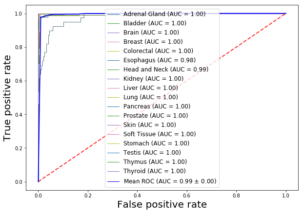

```python
origins = list(average_precision_ser.index)
roc_fname = FIGURE + 'auc_test.png'
plot_auc(origins, fprs, tprs, aucs, tprs_overall, codesfile, True, roc_fname)
```

##### 3.5.2.4 Save results to files (don't run)

```python
# save results to files
# pd.Series(accuracy, index=['accuracy']).to_csv(results_dir + "accuracy.txt", sep="\n")
# cm_df.to_csv(results_dir + "confusion_matrix.csv")
# SSPN_df.to_csv(results_dir + "sspn.csv")
# average_precision_ser.to_csv(results_dir + "average_precision.csv")
# pred_df.to_csv(results_dir + "pred_results.csv", sep=",")
```

#### 3.5.3 Metastatic data from TCGA

##### 3.5.3.1 Get prediction results

```python
testfile = DATA_METASTATIC + 'metastatic_data1.tfrecords'
testmetafile = DATA_METASTATIC + 'metastatic_data1_meta.csv'
sample_size = 143
units = 64
modelfile = MODELS + 'best_model/model_0.ckpt'
codesfile = DATA_TRAIN_DEV_TEST + 'code.csv'
results_dir = RESULTS + 'metastatic/'

# precision, recall, average_precision, SSPN, cm, acc, preds = \
#     cancer_origin_DNN.run_testing(testfile, testmetafile, units, modelfile, sample_size, codesfile)

accuracy, precision, recall, average_precision_ser, cm_df, SSPN_df, pred_df, fprs, tprs, aucs, tprs_overall = \
ModelEval.testeval(testfile, testmetafile, sample_size, units, modelfile, codesfile)
```

```
../data/metastatic/metastatic_data1.tfrecords
../DNN_model/best_model/model_0.ckpt
INFO:tensorflow:Restoring parameters from ../DNN_model/best_model/model_0.ckpt
Iteration: 1
Testing done!
Accuracy: 0.9370629191398621
```

##### 3.5.3.2 Display evaluation metrics

```python
# display metrics
print("\nAccuracy: {}".format(round(accuracy,4)))
print("\nConfusion matrix:")
print(cm_df)
print("\nAverage precision:")
print(average_precision_ser)
print("\n SSPN:\n {}".format(SSPN_df))
```

```
Accuracy: 0.9370999932289124

Confusion matrix:
               Adrenal Gland  Bladder  Breast  Colorectal  Esophagus  \
Adrenal Gland              4        0       0           0          0
Bladder                    0       27       0           0          1
Breast                     0        0       3           0          0
Colorectal                 0        0       0           8          0
Esophagus                  0        0       0           0          2
Head and Neck              0        0       1           0          6
Kidney                     0        0       0           0          0
Liver                      0        0       0           0          0
Lung                       0        0       0           0          0
Pancreas                   0        0       0           0          0
Stomach                    0        0       0           0          0
Thyroid                    0        0       0           0          0

               Head and Neck  Kidney  Liver  Lung  Pancreas  Stomach  Thyroid
Adrenal Gland              0       0      0     0         0        0        0
Bladder                    0       0      0     0         0        0        0
Breast                     0       0      0     0         0        0        0
Colorectal                 0       0      0     0         0        0        0
Esophagus                  0       0      0     0         0        0        0
Head and Neck             53       0      0     0         0        0        0
Kidney                     0      16      0     0         0        0        0
Liver                      0       0      2     0         0        0        0
Lung                       0       0      1     2         0        0        0
Pancreas                   0       0      0     0         1        0        0
Stomach                    0       0      0     0         0        7        0
Thyroid                    0       0      0     0         0        0        9

Average precision:
Adrenal Gland    1.000000
Bladder          0.998768
Breast           0.916667
Colorectal       1.000000
Esophagus        0.750000
Head and Neck    0.991701
Kidney           1.000000
Liver            1.000000
Lung             0.866667
Pancreas         1.000000
Stomach          1.000000
Thyroid          1.000000
Overall          0.976062
dtype: float64

 SSPN:
                Specificity  Sensitivity       PPV       NPV
Adrenal Gland     1.000000     1.000000  1.000000  1.000000
Bladder           1.000000     0.964286  1.000000  0.991379
Breast            0.992857     1.000000  0.750000  1.000000
Colorectal        1.000000     1.000000  1.000000  1.000000
Esophagus         0.950355     1.000000  0.222222  1.000000
Head and Neck     1.000000     0.883333  1.000000  0.922222
Kidney            1.000000     1.000000  1.000000  1.000000
Liver             0.992908     1.000000  0.666667  1.000000
Lung              1.000000     0.666667  1.000000  0.992908
Pancreas          1.000000     1.000000  1.000000  1.000000
Stomach           1.000000     1.000000  1.000000  1.000000
Thyroid           1.000000     1.000000  1.000000  1.000000
Overall           0.994677     0.959524  0.886574  0.992209
```

##### 3.5.3.3 Plot ROC curve

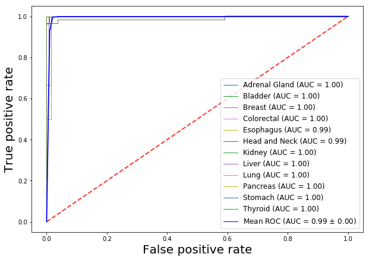

```python
# plot ROC curve
origins = list(average_precision_ser.index)
roc_fname = FIGURE + 'auc_meta.png'
plot_auc(origins, fprs, tprs, aucs, tprs_overall, codesfile, True, roc_fname)
```

##### 3.5.3.4 Save results to files (don't run)

```python
# save results to files
# pd.Series(accuracy, index=['accuracy']).to_csv(results_dir + "accuracy.txt", sep="\n")
# cm_df.to_csv(results_dir + "confusion_matrix.csv")
# SSPN_df.to_csv(results_dir + "sspn.csv")
# average_precision_ser.to_csv(results_dir + "average_precision.csv")
# pred_df.to_csv(results_dir + "pred_results.csv", sep=",")
```

#### 3.5.4 Test data from GEO

##### 3.5.4.1 Get prediction results

```python
testfile = DATA_GEO + 'GEO_combined_final.tfrecords'
testmetafile = DATA_GEO + 'GEO_combined_final_meta.csv'
sample_size = 581
units = 64
modelfile = MODELS + '/best_model/model_0.ckpt'
codesfile = DATA_TRAIN_DEV_TEST + 'code.csv'
results_dir = RESULTS + 'GEO/'

accuracy, precision, recall, average_precision_ser, cm_df, SSPN_df, pred_df, fprs, tprs, aucs, tprs_overall = \
ModelEval.testeval(testfile, testmetafile, sample_size, units, modelfile, codesfile)
```

```
../data/GEO/GEO_combined_final.tfrecords
../DNN_model//best_model/model_0.ckpt
INFO:tensorflow:Restoring parameters from ../DNN_model//best_model/model_0.ckpt
Iteration: 1
Testing done!
Accuracy: 0.9259896874427795
```

##### 3.5.4.2 Display evaluation metrics

```python
# display metrics
print("\nAccuracy: {}".format(round(accuracy,4)))
print("\nConfusion matrix:")
print(cm_df)
print("\nAverage precision:")
print(average_precision_ser)
print("\n SSPN:\n {}".format(SSPN_df))
```

```
Accuracy: 0.9259999990463257

Confusion matrix:
               Adrenal Gland  Bladder  Breast  Colorectal  Head and Neck  \
Adrenal Gland             14        0       0           0              0
Bladder                    0       25       0           0              0
Breast                     0        0      34           0              0
Colorectal                 0        0       1         108              0
Head and Neck              0        0       0           0              5
Kidney                     0        0       0           0              0
Liver                      0        0       0           0              0
Lung                       0        0       0           0              0
Pancreas                   0        0       0           0              0
Prostate                   0        0       0           0              0
Soft Tissue                0        0       0           0              0
Stomach                    0        0       0           0              0
Thyroid                    0        0       1           0              0

               Kidney  Liver  Lung  Pancreas  Prostate  Soft Tissue  Stomach  \
Adrenal Gland       0      0     2         0         0            2        0
Bladder             0      0     0         0         0            0        0
Breast              0      0     1         0         0            0        0
Colorectal          0      0     1         0         0            0        2
Head and Neck       0      0     1         0         0            0        0
Kidney             17      0     0         0         0            0        0
Liver               0     37     0         0         0            0        0
Lung                0      0     0         0         0            0        0
Pancreas            0      3     6       135         0            0       23
Prostate            0      0     0         0        82            0        0
Soft Tissue         0      0     0         0         0            0        0
Stomach             0      0     0         0         0            0        0
Thyroid             0      0     0         0         0            0        0

               Thyroid
Adrenal Gland        0
Bladder              0
Breast               0
Colorectal           0
Head and Neck        0
Kidney               0
```

[output cut: 20 more lines]

```
dtype: float64

 SSPN:
                Specificity  Sensitivity       PPV       NPV
Adrenal Gland     1.000000     0.777778  1.000000  0.992945
Bladder           1.000000     1.000000  1.000000  1.000000
Breast            0.996337     0.971429  0.944444  0.998165
Colorectal        1.000000     0.964286  1.000000  0.991543
Head and Neck     1.000000     0.833333  1.000000  0.998264
Kidney            1.000000     1.000000  1.000000  1.000000
Liver             0.994485     1.000000  0.925000  1.000000
Pancreas          1.000000     0.808383  1.000000  0.928251
Prostate          1.000000     1.000000  1.000000  1.000000
Thyroid           1.000000     0.987805  1.000000  0.998000
Overall           0.999082     0.934301  0.986944  0.990717
```

##### 3.5.4.3 Plot ROC curve

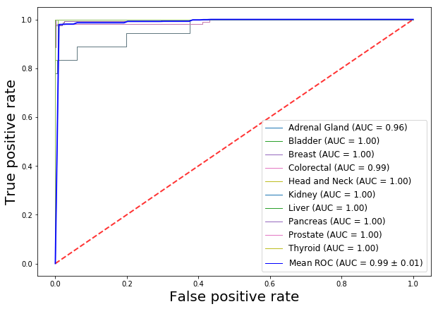

```python
# plot ROC curve
origins = list(average_precision_ser.index)
roc_fname = FIGURE + 'auc_geo.png'
plot_auc(origins, fprs, tprs, aucs, tprs_overall, codesfile, True, roc_fname)
```

##### 3.5.2.4 Save results to files (don't run)

```python
# save results to files
# pd.Series(accuracy, index=['accuracy']).to_csv(results_dir + "accuracy.txt", sep="\n")
# cm_df.to_csv(results_dir + "confusion_matrix.csv")
# SSPN_df.to_csv(results_dir + "sspn.csv")
# average_precision_ser.to_csv(results_dir + "average_precision.csv")
# pred_df.to_csv(results_dir + "pred_results.csv", sep=",")
```